# MovieLens Project Questions

### `Project - MovieLens Data Analysis`

The GroupLens Research Project is a research group in the Department of Computer Science and Engineering at the University of Minnesota. The data is widely used for collaborative filtering and other filtering solutions. However, we will be using this data to act as a means to demonstrate our skill in using Python to “play” with data.

### `Objective:`

- To implement the techniques learnt as a part of the course.

### `Learning Outcomes:`

- Exploratory Data Analysis
- Visualization using Python
- Pandas – groupby, merging

### `Domain`

- Internet and Entertainment

**Note that the project will need you to apply the concepts of groupby and merging extensively.**

### `Datasets Information:`

*rating.csv:* It contains information on ratings given by the users to a particular movie.

- user id: id assigned to every user
- movie id: id assigned to every movie
- rating: rating given by the user
- timestamp: Time recorded when the user gave a rating

*movie.csv:* File contains information related to the movies and their genre.

- movie id: id assigned to every movie
- movie title: Title of the movie
- release date: Date of release of the movie
- Action: Genre containing binary values (1 - for action 0 - not action)
- Adventure: Genre containing binary values (1 - for adventure 0 - not adventure)
- Animation: Genre containing binary values (1 - for animation 0 - not animation)
- Children’s: Genre containing binary values (1 - for children's 0 - not children's)
- Comedy: Genre containing binary values (1 - for comedy 0 - not comedy)
- Crime: Genre containing binary values (1 - for crime 0 - not crime)
- Documentary: Genre containing binary values (1 - for documentary 0 - not documentary)
- Drama: Genre containing binary values (1 - for drama 0 - not drama)
- Fantasy: Genre containing binary values (1 - for fantasy 0 - not fantasy)
- Film-Noir: Genre containing binary values (1 - for film-noir 0 - not film-noir)
- Horror: Genre containing binary values (1 - for horror 0 - not horror)
- Musical: Genre containing binary values (1 - for musical 0 - not musical)
- Mystery: Genre containing binary values (1 - for mystery 0 - not mystery)
- Romance: Genre containing binary values (1 - for romance 0 - not romance)
- Sci-Fi: Genre containing binary values (1 - for sci-fi 0 - not sci-fi)
- Thriller: Genre containing binary values (1 - for thriller 0 - not thriller)
- War: Genre containing binary values (1 - for war 0 - not war)
- Western: Genre containing binary values (1 - for western - not western)

*user.csv:* It contains information of the users who have rated the movies.

- user id: id assigned to every user
- age: Age of the user
- gender: Gender of the user
- occupation: Occupation of the user
- zip code: Zip code of the use

**`Please provide you insights wherever necessary.`**

### 1. Import the necessary packages - 2.5 marks

```python
# Charles Tewksbury     Project 1

import pandas as pd     # PANDAS - Data analysis and manipulation tool
import seaborn as sns   # SEABORN - Data visualization Library
import matplotlib.pyplot as plt   # MATPLOTLIB.PYPLOT - Interactive plots library
```

### 2. Read the 3 datasets into dataframes - 2.5 marks

```python
# Read in CSV Files
data = pd.read_csv("data.csv")   # User <-> Movie rating table
item = pd.read_csv("item.csv")   # Movie information table
user = pd.read_csv("user.csv")   # User information table
```

### 3. Apply info, shape, describe, and find the number of missing values in the data - 5 marks

- Note that you will need to do it for all the three datasets seperately

```python
# Utilize pandas.DataFrame.info to get index dtype and columns, non-null values and memory usage
print("Print a concise summary of the loaded DataFrames via info()\n")

# data Information
print("*************** DATA INFO ***************")
print(data.info())
print("\n")

# data Information
print("*************** ITEM INFO ***************")
print(item.info())
print("\n")

# data Information
print("*************** USER INFO ***************")
print(user.info())
print("\n")
```

```
Print a concise summary of the loaded DataFrames via info()

*************** DATA INFO ***************
<class 'pandas.core.frame.DataFrame'>
RangeIndex: 100000 entries, 0 to 99999
Data columns (total 4 columns):
 #   Column     Non-Null Count   Dtype
---  ------     --------------   -----
 0   user id    100000 non-null  int64
 1   movie id   100000 non-null  int64
 2   rating     100000 non-null  int64
 3   timestamp  100000 non-null  int64
dtypes: int64(4)
memory usage: 3.1 MB
None


*************** ITEM INFO ***************
<class 'pandas.core.frame.DataFrame'>
RangeIndex: 1681 entries, 0 to 1680
Data columns (total 22 columns):
 #   Column        Non-Null Count  Dtype
---  ------        --------------  -----
 0   movie id      1681 non-null   int64
 1   movie title   1681 non-null   object
 2   release date  1681 non-null   object
 3   unknown       1681 non-null   int64
 4   Action        1681 non-null   int64
 5   Adventure     1681 non-null   int64
 6   Animation     1681 non-null   int64
 7   Childrens     1681 non-null   int64
 8   Comedy        1681 non-null   int64
 9   Crime         1681 non-null   int64
 10  Documentary   1681 non-null   int64
 11  Drama         1681 non-null   int64
 12  Fantasy       1681 non-null   int64
 13  Film-Noir     1681 non-null   int64
 14  Horror        1681 non-null   int64
 15  Musical       1681 non-null   int64
 16  Mystery       1681 non-null   int64
```

[output cut: 9 more lines]

```

*************** USER INFO ***************
<class 'pandas.core.frame.DataFrame'>
RangeIndex: 943 entries, 0 to 942
Data columns (total 5 columns):
 #   Column      Non-Null Count  Dtype
---  ------      --------------  -----
 0   user id     943 non-null    int64
 1   age         943 non-null    int64
 2   gender      943 non-null    object
 3   occupation  943 non-null    object
 4   zip code    943 non-null    object
dtypes: int64(2), object(3)
memory usage: 37.0+ KB
None
```

```python
# Utilize pandas.DataFrame.shape to print a tuple representing the dimensionality of the DataFrame
print("Print the shapes of the loaded DataFrames via the shape property\n")

# data Shape
print("*************** DATA Shape ***************")
print(data.shape)
print("\n")

# item Shape
print("*************** ITEM Shape ***************")
print(item.shape)
print("\n")

# user Shape
print("*************** USER Shape ***************")
print(user.shape)
print("\n")
```

```
Print the shapes of the loaded DataFrames via the shape property

*************** DATA Shape ***************
(100000, 4)


*************** ITEM Shape ***************
(1681, 22)


*************** USER Shape ***************
(943, 5)
```

```python
# Utilize pandas.DataFrame.describe() to print Descriptive statistic of the loaded Dataframes
print("Print the summary of the central tendency, dispersion and shape of a dataset’s distribution, excluding NaN values of the loaded DataFrames.\n")

# data Description
print("*************** DATA Description ***************")
print(data.describe())
print("\n")

# item Description
print("*************** ITEM Description ***************")
print(item.describe())
print("\n")

# suer Description
print("*************** USER Description ***************")
print(user.describe())
print("\n")
```

```
Print the summary of the central tendency, dispersion and shape of a dataset’s distribution, excluding NaN values of the loaded DataFrames.

*************** DATA Description ***************
            user id       movie id         rating     timestamp
count  100000.00000  100000.000000  100000.000000  1.000000e+05
mean      462.48475     425.530130       3.529860  8.835289e+08
std       266.61442     330.798356       1.125674  5.343856e+06
min         1.00000       1.000000       1.000000  8.747247e+08
25%       254.00000     175.000000       3.000000  8.794487e+08
50%       447.00000     322.000000       4.000000  8.828269e+08
75%       682.00000     631.000000       4.000000  8.882600e+08
max       943.00000    1682.000000       5.000000  8.932866e+08


*************** ITEM Description ***************
          movie id      unknown       Action    Adventure    Animation  \
count  1681.000000  1681.000000  1681.000000  1681.000000  1681.000000
mean    841.841761     0.000595     0.149316     0.080309     0.024985
std     485.638077     0.024390     0.356506     0.271852     0.156126
min       1.000000     0.000000     0.000000     0.000000     0.000000
25%     422.000000     0.000000     0.000000     0.000000     0.000000
50%     842.000000     0.000000     0.000000     0.000000     0.000000
75%    1262.000000     0.000000     0.000000     0.000000     0.000000
max    1682.000000     1.000000     1.000000     1.000000     1.000000

         Childrens       Comedy        Crime  Documentary        Drama  \
count  1681.000000  1681.000000  1681.000000  1681.000000  1681.000000
mean      0.072576     0.300416     0.064842     0.029744     0.431291
std       0.259516     0.458576     0.246321     0.169931     0.495404
min       0.000000     0.000000     0.000000     0.000000     0.000000
25%       0.000000     0.000000     0.000000     0.000000     0.000000
50%       0.000000     0.000000     0.000000     0.000000     0.000000
75%       0.000000     1.000000     0.000000     0.000000     1.000000
max       1.000000     1.000000     1.000000     1.000000     1.000000

           Fantasy    Film-Noir       Horror      Musical      Mystery  \
count  1681.000000  1681.000000  1681.000000  1681.000000  1681.000000
mean      0.013087     0.014277     0.054729     0.033314     0.036288
std       0.113683     0.118667     0.227519     0.179507     0.187061
min       0.000000     0.000000     0.000000     0.000000     0.000000
```

[output cut: 11 more lines]

```
50%       0.000000     0.000000     0.000000     0.000000     0.000000
75%       0.000000     0.000000     0.000000     0.000000     0.000000
max       1.000000     1.000000     1.000000     1.000000     1.000000


*************** USER Description ***************
          user id         age
count  943.000000  943.000000
mean   472.000000   34.051962
std    272.364951   12.192740
min      1.000000    7.000000
25%    236.500000   25.000000
50%    472.000000   31.000000
75%    707.500000   43.000000
max    943.000000   73.000000
```

```python
# Utilize pandas.DataFrame.isnull() to print amount of null values in the loaded Dataframes
print("Print amount of nulls of the loaded DataFrames.\n")


# data Nulls
print("*************** DATA NULL INFO ***************")
print(data.isnull().sum())
print("\n\n")

# item nulls
print("*************** ITEM NULL INFO ***************")
print(item.isnull().sum())
print("\n")

# user Nulls
print("*************** USER NULL INFO ***************")
print(user.isnull().sum())
print("\n")
```

```
Print amount of nulls of the loaded DataFrames.

*************** DATA NULL INFO ***************
user id      0
movie id     0
rating       0
timestamp    0
dtype: int64



*************** ITEM NULL INFO ***************
movie id        0
movie title     0
release date    0
unknown         0
Action          0
Adventure       0
Animation       0
Childrens       0
Comedy          0
Crime           0
Documentary     0
Drama           0
Fantasy         0
Film-Noir       0
Horror          0
Musical         0
Mystery         0
Romance         0
Sci-Fi          0
Thriller        0
War             0
Western         0
dtype: int64


*************** USER NULL INFO ***************
user id       0
age           0
gender        0
occupation    0
zip code      0
dtype: int64
```

### 4. Find the number of movies per genre using the item data - 2.5 marks

```python
# Derermine the total number of movies per genre utilizing the item dataframe

print("***************  Number of movies per genre *************** \n")
print(item.drop(columns=['movie id','movie title','release date']).sum())
```

```
***************  Number of movies per genre ***************

unknown          1
Action         251
Adventure      135
Animation       42
Childrens      122
Comedy         505
Crime          109
Documentary     50
Drama          725
Fantasy         22
Film-Noir       24
Horror          92
Musical         56
Mystery         61
Romance        247
Sci-Fi         101
Thriller       251
War             71
Western         27
dtype: int64
```

### 5. Drop the movie where the genre is unknown - 2.5 marks

```python
# Drop the unknown genre movie

print("*************** Remove movies with unknown genre from dataframe ***************\n ")

item.drop(item[ item['unknown'] >= 1 ].index , inplace = True)   # item[ item['unknown'] >= 1 ].index - Find the index of all rows conaining a unknown value equal to greater than 1

print("Display count of movies per genre to display that unknown has no entries")
item.sum()
```

```
***************  Remove movies with unknown genre from dataframe ***************

Display count of movies per genre to display that unknown has no entries
```

```
movie id                                                  1413763
movie title     Toy Story GoldenEye Four Rooms Get Shorty Copy...
release date    01-Jan-199501-Jan-199501-Jan-199501-Jan-199501...
unknown                                                         0
Action                                                        251
Adventure                                                     135
Animation                                                      42
Childrens                                                     122
Comedy                                                        505
Crime                                                         109
Documentary                                                    50
Drama                                                         725
Fantasy                                                        22
Film-Noir                                                      24
Horror                                                         92
Musical                                                        56
Mystery                                                        61
Romance                                                       247
Sci-Fi                                                        101
Thriller                                                      251
War                                                            71
Western                                                        27
dtype: object
```

### 6. Find the movies that have more than one genre - 5 marks

hint: use sum on the axis = 1

Display movie name, number of genres for the movie in dataframe

and also print(total number of movies which have more than one genres)

```python
# Print movies catagorized as being in more than one genre.
# Mentioned where pertinent below but this assumes each genre can only have a 0 or 1 at initilaization.

pd.set_option('display.max_columns', None) # used to keep from truncating display of genre columns

mitem = item.copy()   # Copying item dataframe ot a temp dataframe as want movie id in later usage.
mitem.drop(columns=['movie id'], inplace=True) #Remove column 'movie id' so row sums will not be influcned by simple id.

# Remove the 'Number of Genres' column IF it exists so we do not get potential double counts from multiple runs.
# In all ikelhood this isn't needed, but using as a error prevention.
if 'Number of Genres' in mitem.columns:
    mitem.drop(columns=['Number of Genres'], inplace=True)

mitem['Number of Genres'] = mitem.sum(axis=1) # Sum up the genres per row

mitem = mitem.loc[mitem['Number of Genres'] > 1]  # Only maintain those rows that have more than one genre via the sum.
# In reality, this assumes each genre can only have a 0 or 1 at initilaization.  Future work would potentially check for this.

print('\nResult dataframe :\n', mitem[['movie title','Number of Genres']])

print("\nTotal Number of multi-genre movies=", len(mitem) )
```

```
Result dataframe :
                                             movie title  Number of Genres
0                                            Toy Story                  3
1                                            GoldenEye                  3
3                                           Get Shorty                  3
4                                              Copycat                  3
6                                       Twelve Monkeys                  2
7                                                 Babe                  3
9                                          Richard III                  2
10                                       Seven (Se7en)                  2
11                                 Usual Suspects, The                  2
13                                         Postino, Il                  2
15                         French Twist (Gazon maudit)                  2
16                                 From Dusk Till Dawn                  5
19                                  Angels and Insects                  2
```

[output cut: 838 more lines]

### 7. Univariate plots of columns: 'rating', 'Age', 'release year', 'Gender' and 'Occupation' - 10 marks

*HINT: Use distplot for age. Use lineplot or countplot for release year.*

*HINT: Plot percentages in y-axis and categories in x-axis for ratings, gender and occupation*

*HINT: Please refer to the below snippet to understand how to get to release year from release date. You can use str.split() as depicted below or you could convert it to pandas datetime format and extract year (.dt.year)*

```
*************** Graph of Numbers of Ratings vs Score of Rating ***************
```

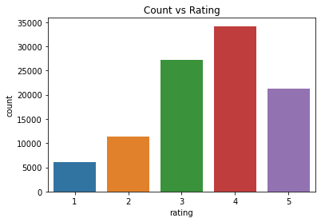

```python
print("*************** Graph of Numbers of Ratings vs Score of Rating *************** ")
p_rating = sns.countplot(data['rating']).set_title("Count vs Rating")

# graph does display that the mean ratng is bewteen 3 and 4, matching our earlier finding.
```

```
*************** Graph of distribution of age of users ***************
```

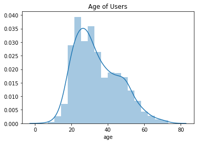

```python
print("*************** Graph of distribution of age of users *************** ")
p_age = sns.distplot(user['age']).set_title("Age of Users")
```

```
*************** Graph of number of rated films released per year ***************
```

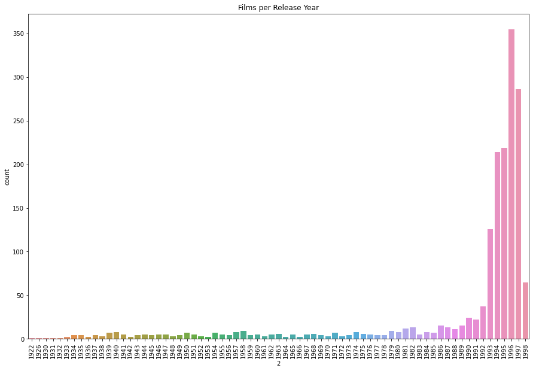

```python
print("*************** Graph of number of rated films released per year *************** ")


# Take the DD-Mon-YYYY format and convert it to individual columms.
# Place these colmns ina new table so as to not destoy orginal data
item_date = item['release date'].str.split('-', expand=True)

plt.figure(figsize=(15,10))       # Make graph bigger
plt.xticks(rotation=90)           # Rotate year dispaly for clairity

p_date = sns.countplot(item_date[2]).set_title("Films per Release Year")  # Run the count plot o the year column
```

```
*************** Graph of number of each gender in the user CSV ***************
```

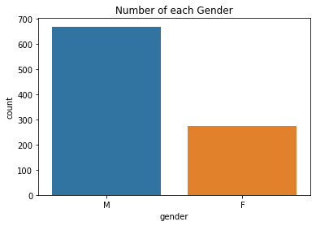

```python
print("*************** Graph of number of each gender in the user CSV *************** ")

p_gender = sns.countplot(user['gender']).set_title("Number of each Gender")
```

```
*************** Graph of number of members of each occupations in the user CSV ***************
```

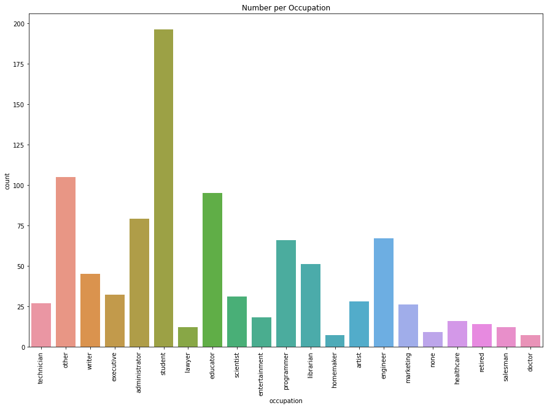

```python
print("*************** Graph of number of members of each occupations in the user CSV *************** ")

plt.figure(figsize=(15,10))       # Make graph bigger
plt.xticks(rotation=90)           # Rotate year dispaly for clairity
p_ocupation = sns.countplot(user['occupation']).set_title("Number per Occupation")
```

### 8. Visualize how popularity of genres has changed over the years - 10 marks

Note that you need to use the **percent of number of releases in a year** as a parameter of popularity of a genre

Hint 1: You need to reach to a data frame where the release year is the index and the genre is the column names (one cell shows the number of release in a year in one genre) or vice versa. (Drop unnecessary column if there are any)

Hint 2: Find the total number of movies release in a year(use `sum(axis=1)` store that value in a new column as 'total'). Now divide the value of each genre in that year by total to get percentage number of release in a particular year. `(df.div(df['total'], axis= 0) * 100)`

Once that is achieved, you can either use univariate plots or can use the heatmap to visualise all the changes over the years in one go.

Hint 3: Use groupby on the relevant column and use sum() on the same to find out the number of releases in a year/genre.

```python
# Visudalize how genre populatroty has changed over the years.
# USe genre as a percentage of releases per year to determine this.

g_item = item.copy()   # Copy item into a temporary data frame as do not wna to destroy orginal DF.

# Take the DD-Mon-YYYY format and convert it to individual columms.
# Place these colmns ina new table so as to not destoy orginal data
g_item['release year'] = g_item['release date'].str.split('-').str[2]   #Split out the year



g_item.drop(columns=['movie id', 'movie title', 'release date'], inplace=True) # Drop unused columns
g_item.set_index(g_item['release year'], inplace=True) #S et the index otthe relase year so we can group these by year

g_item = g_item.groupby(g_item['release year']).sum()  #Group by year and then sum remain columns to get totla movies per genre per year
g_item['total movies'] = g_item.sum(axis=1) # Sum all movies ot get a tioal count so can figure percentage.
g_item = g_item.div(g_item['total movies'], axis= 0) * 100   #Determine percentage and display as %
print(g_item)  #Print the table just for sanity sake
```

```
               unknown     Action  Adventure  Animation  Childrens     Comedy  \
release year
1922          0.000000   0.000000   0.000000   0.000000   0.000000   0.000000
1926          0.000000   0.000000   0.000000   0.000000   0.000000   0.000000
1930          0.000000   0.000000   0.000000   0.000000   0.000000   0.000000
1931          0.000000   0.000000   0.000000   0.000000   0.000000   0.000000
1932          0.000000   0.000000   0.000000   0.000000   0.000000   0.000000
1933          0.000000   0.000000   0.000000   0.000000   0.000000  33.333333
1934          0.000000   0.000000   0.000000   0.000000   0.000000  33.333333
1935          0.000000   0.000000   0.000000   0.000000   0.000000  33.333333
1936          0.000000   0.000000   0.000000   0.000000   0.000000  50.000000
1937          0.000000   0.000000   0.000000  10.000000  10.000000  20.000000
1938          0.000000  25.000000  25.000000   0.000000   0.000000  25.000000
1939          0.000000   0.000000   6.666667   0.000000  13.333333  13.333333
1940          0.000000   0.000000   7.692308  15.384615  15.384615  23.076923
```

[output cut: 280 more lines]

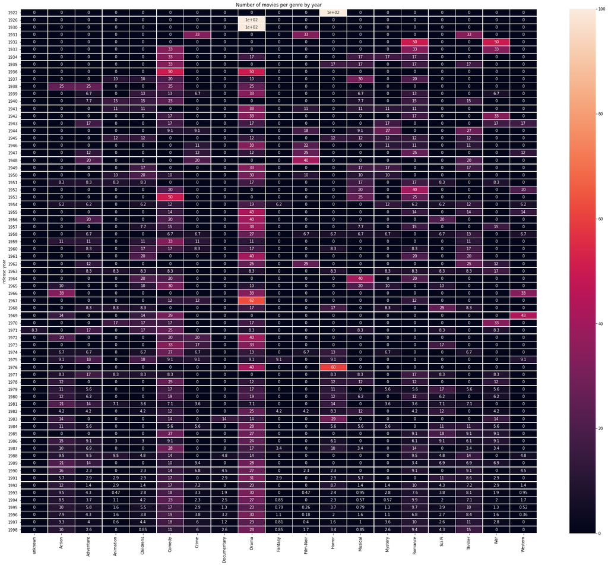

```python
# Display a heat map to vusally observe how the mvoie genre popularity has changed

# Protecting code via teh if statement as notice multiple runs can casue erros as colmn had been previously removed.
# POtentially fix this by setting up datamap in same cell but want the previous graph display as well and seems eaier unde  multiple cells.
if 'total movies' in g_item.columns:
    g_item.drop(columns = "total movies", inplace=True) # Dop the "total movies column" as doesn't really porvide any data ot the graph

f, ax = plt.subplots(figsize=(30, 25))
plt.xticks(rotation=90)           # Rotate year dispaly for clairity

print(sns.heatmap(g_item, annot=True, linewidths=.5, ax=ax).set_title("Number of movies per genre by year"))
```

### 9. Find the top 25 movies according to average ratings such that each movie has number of ratings more than 100 - 10 marks

Hints :

1. Find the count of ratings and average ratings for every movie.
2. Slice the movies which have ratings more than 100.
3. Sort values according to average rating such that movie which highest rating is on top.
4. Select top 25 movies.
5. You will have to use the .merge() function to get the movie titles.

Note: This question will need you to research about groupby and apply your findings. You can find more on groupby on https://realpython.com/pandas-groupby/.

```python
# Find top 25 movies with at least 100 ratings

# Assignign a temp data rame to data as to not destroy orginal dataframe which wil be needed in next question.
# This section is to get the total number of ratings per movie. It will be used to get items with more than 100 movies later
# tmppdata propbably isn't needed and could be included into the a_data df, whcih woudl ermove the merge but this was "safer" and easier
# to implement.
tmpdata = data.copy()
tmpdata['Rating Count'] = 1   # Add a column named arting count to allow average calculation later. Will be based on total movies fopr that row
tmpdata.drop(columns=['user id', 'rating','timestamp'], inplace=True) #Drop uneeded columns
tmpdata = tmpdata.groupby('movie id').sum()  #
tmpdata.reset_index(inplace=True)

# Assigning a temp dataframe to data as to not destroy orginal dataframe which wil be needed in next question.
a_data = data.groupby(data['movie id']).mean()   #get the average rating per movie
a_data.rename(columns={"rating": "Average Rating"}, inplace=True) #Rename the column just for accuracy.
a_data.drop(columns=['user id','timestamp'], inplace=True) # Delete uneeded columns

a_data.reset_index(inplace=True) # Setting up to allow easier merging

a_data= a_data.merge(tmpdata, left_on="movie id",right_on="movie id")  # Merge the average data frame with the total count data frame


nogo = a_data[ a_data['Rating Count'] <= 100 ].index  # Determine the index of all movies in dataframe that do not have more than 100 ratings
a_data.drop(nogo , inplace=True) # Delete these row indexes from dataFrame

# Need to merge  item dataframe in to get movie titles for display.
a_data= a_data.merge(item, left_on="movie id",right_on="movie id")
a_data.drop(columns=['movie id', 'release date','unknown','Action','Adventure','Animation','Childrens','Comedy','Crime','Documentary','Drama','Fantasy','Film-Noir','Horror','Musical','Mystery','Romance','Sci-Fi','Thriller','War','Western'], inplace=True) # Drop unuised columns

a_data.set_index('movie title', inplace=True) # Set movie tiotle as index justto make printign look better.
a_data.sort_values(by=['Average Rating'],ascending=False).head(25) # Display Top 25 Average rated movies
```

| movie title | Average Rating | Rating Count |
| --- | --- | --- |
| Close Shave, A | 4.491071 | 112 |
| Schindler's List | 4.466443 | 298 |
| Wrong Trousers, The | 4.466102 | 118 |
| Casablanca | 4.456790 | 243 |
| Shawshank Redemption, The | 4.445230 | 283 |
| Rear Window | 4.387560 | 209 |
| Usual Suspects, The | 4.385768 | 267 |
| Star Wars | 4.358491 | 583 |
| 12 Angry Men | 4.344000 | 125 |
| Citizen Kane | 4.292929 | 198 |
| To Kill a Mockingbird | 4.292237 | 219 |
| One Flew Over the Cuckoo's Nest | 4.291667 | 264 |
| Silence of the Lambs, The | 4.289744 | 390 |
| North by Northwest | 4.284916 | 179 |
| Godfather, The | 4.283293 | 413 |
| Secrets & Lies | 4.265432 | 162 |
| Good Will Hunting | 4.262626 | 198 |
| Manchurian Candidate, The | 4.259542 | 131 |
| Dr. Strangelove or: How I Learned to Stop Worrying and Love the Bomb | 4.252577 | 194 |
| Raiders of the Lost Ark | 4.252381 | 420 |
| Vertigo | 4.251397 | 179 |
| Titanic | 4.245714 | 350 |
| Lawrence of Arabia | 4.231214 | 173 |
| Maltese Falcon, The | 4.210145 | 138 |
| Empire Strikes Back, The | 4.204360 | 367 |

### 10. See gender distribution across different genres check for the validity of the below statements - 10 marks

- Men watch more drama than women
- Women watch more Sci-Fi than men
- Men watch more Romance than women

**compare the percentages**

1. Merge all the datasets
2. There is no need to conduct statistical tests around this. Just **compare the percentages** and comment on the validity of the above statements.
3. you might want ot use the .sum(), .div() function here.
4. Use number of ratings to validate the numbers. For example, if out of 4000 ratings received by women, 3000 are for drama, we will assume that 75% of the women watch drama.

```python
# Check gender distribution for three categories of movies.
#First set up a singular dataframe of all three (user, item and data) other datframes
#Common keys are:
#    user <-> data = user_id
#    item <-> (user <-> data) = movie_id

# validating that each merge is 1 to many ot ensure that comon dat gets distributed to each row that has a same key.
newdf = user.merge(data, left_on='user id', right_on='user id', validate="1:m")
newdf = item.merge(newdf, left_on='movie id', right_on='movie id', validate="1:m")

# For the next several calculations, set a new datframe for each category based on "newdf" rather than use "newdf" itslef so can maintain its integrity for future calcs.
```

```python
########### DRAMA
# Check Male to Female RAW numbers for Drama movies

newdf1 = newdf.groupby(["gender","Drama"])["Drama"].count()
newdf1
```

```
gender  Drama
F       0        14730
        1        11008
M       0        45366
        1        28887
Name: Drama, dtype: int64
```

```python
# Determine percentage of men and women in Drama
# Note: This is GENDER / (GENDER RATE + GENDER NO RATE) therefore it is percentage of each gender and ot of total number of people
# In other words although there are fewer women making ratings the data is normalized with men so percentage have same weigth.
wy = (newdf1.iloc[1] / (newdf1.iloc[0] + newdf1.iloc[1]))*100  # F Rows (0 = no rating, 1 = rating)
my = (newdf1.iloc[3] / (newdf1.iloc[2] + newdf1.iloc[3]))*100  # M Rows (0 = no rating, 1 = rating)

print("Male Percentage = %s, Female Percentage = %s. Men watch more Drama is %s" % (my, wy, my > wy))
```

```
Male Percentage = 38.90347864732738, Female Percentage = 42.76944595539669. Men watch more Drama is False
```

```python
########### SCI FI
# Check Male to Female RAW numbers for Sci-Fi movies

newdf2 = newdf.groupby(["gender","Sci-Fi"])["Sci-Fi"].count()
newdf2
```

```
gender  Sci-Fi
F       0         23109
        1          2629
M       0         64152
        1         10101
Name: Sci-Fi, dtype: int64
```

```python
# Determine percentage of men and women in Sci-Fi
# Note: This is GENDER / (GENDER RATE + GENDER NO RATE) therefore it is percentage of each gender and ot of total number of people
# In other words although there are fewer women making ratings the data is normalized with men so percentage have same weigth.
wy = (newdf2.iloc[1] / (newdf2.iloc[0] + newdf2.iloc[1]))*100  # F Rows (0 = no rating, 1 = rating)
my = (newdf2.iloc[3] / (newdf2.iloc[2] + newdf2.iloc[3]))*100  # M Rows (0 = no rating, 1 = rating)

print("Male Percentage = %s, Female Percentage = %s. Women watch more Sci-Fi is %s" % (my, wy, wy > my))
```

```
Male Percentage = 13.603490768049776, Female Percentage = 10.214468878700753. Women watch more Sci-Fi is False
```

```python
########### ROMANCE
# Check Male to Female RAW numbers for Romance movies

newdf3 = newdf.groupby(["gender","Romance"])["Romance"].count()
newdf3
```

```
gender  Romance
F       0          19880
        1           5858
M       0          60650
        1          13603
Name: Romance, dtype: int64
```

```python
# Determine percentage of men and women in Romance
# Note: This is GENDER / (GENDER RATE + GENDER NO RATE) therefore it is percentage of each gender and ot of total number of people
# In other words although there are fewer women making ratings the data is normalized with men so percentage have same weigth.
wy = (newdf3.iloc[1] / (newdf3.iloc[0] + newdf3.iloc[1]))*100
my = (newdf3.iloc[3] / (newdf3.iloc[2] + newdf3.iloc[3]))*100
#print("Men Percentage = %s, Woman Percentage = %s, Men is greater = %s" % my, wy, my > wy)
print("Men Percentage = %s, Woman Percentage = %s. Men watch more Romance is %s" % (my, wy, my > wy))
```

```
Men Percentage = 18.319798526658857, Woman Percentage = 22.760121221540135. Men watch more Romance is False
```

```python
print("End of Project 1 for Charles Tewksbury")
```

```
End of Project 1 for Charles Tewksbury
```